# Homework 2

```r
s$duals.from
```

```
## [1]  6.000000e+02  6.666667e+02 -1.000000e+30 -1.000000e+30 -1.000000e+30
```

```r
s$duals.to
```

```
## [1] 1.2e+03 1.6e+03 1.0e+30 1.0e+30 1.0e+30
```

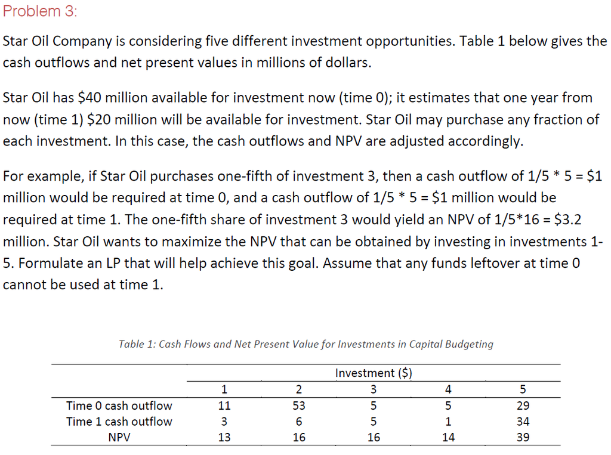

Star Oil should purchase 1.0000000, 0.2008600, 1.0000000, 1.0000000, and 0.2880835 of investment 1, 2, 3, 4, and 5, which would yield a NPV of $57.45M.

Choose: x1, …, x5  
Objective: max 13x1 + 16x2 + 16x3 + 14x4 + 39x5  
Constraints:  
11x1 + 53x2 + 5x3 + 5x4 + 29x5 <= 40  
3x1 + 6x2 + 5x3 + x4 + 34x5 <= 20  
x1, x2, x3, x4, x5 <= 1  
x1, x2, x3, x4, x5 >= 0

```r
c <- c(13, 16, 16, 14, 39)
A <- matrix(c(11, 3, 1, 0, 0, 0, 0, 53, 6, 0, 1, 0, 0, 0, 5, 5, 0, 0, 1, 0, 0, 5, 1, 0, 0, 0, 1, 0, 29, 34, 0, 0, 0, 0, 1), 7, 5)
dir <- rep("<=", 7)
b <- c(40, 20, 1, 1, 1, 1, 1)
s <- lp("max", c, A, dir, b, all.int=FALSE)
s$solution
```

```
## [1] 1.0000000 0.2008600 1.0000000 1.0000000 0.2880835
```

```r
s$objval
```

```
## [1] 57.44902
```

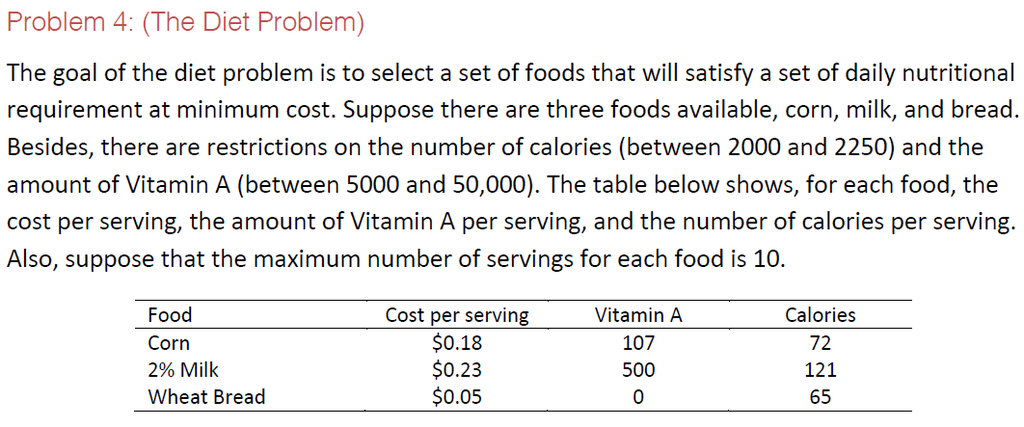

The optimal diet is 1.94 servings of corn, 10 servings of milk, and 10 servings of bread, which would cost $3.15.

Choose: c, m, b  
Objective: min 0.18c + 0.23m + 0.05b  
Constraints:  
72c + 121m + 65b >= 2000  
72c + 121m + 65b <= 2250  
107c + 500m >= 5000  
107c + 500m <= 50000  
c, m, b <= 10

```r
c <- c(.18, .23, .05)
A <- matrix(c(72, 72, 107, 107, 1, 0, 0, 121, 121, 500, 500, 0, 1, 0, 65, 65, 0, 0, 0, 0, 1), 7, 3)
dir <- c(">=", "<=", ">=", "<=", "<=", "<=", "<=")
b <- c(2000, 2250, 5000, 50000, 10, 10, 10)
s <- lp("min", c, A, dir, b)
s$solution
```

```
## [1]  1.944444 10.000000 10.000000
```

```r
s$objval
```

```
## [1] 3.15
```

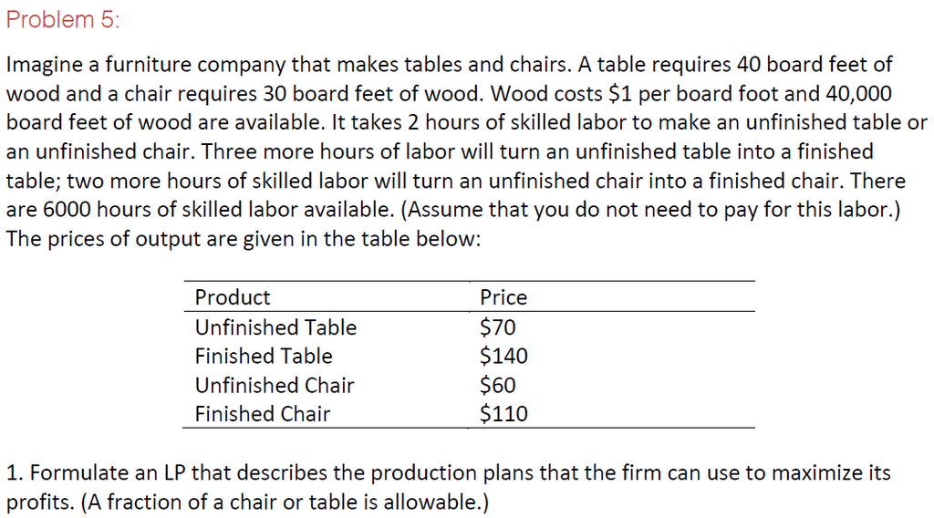

The furniture company should produce 1,333.33 finished chairs to generate $106,666.70 in profit.

```r
c <- c(30, 100, 30, 80)
A <- matrix(c(40, 20, 40, 5, 30, 2, 30, 4), 2, 4)
dir <- c("<=", "<=")
b <- c(40000, 6000)
s <- lp("max", c, A, dir, b, compute.sens=1)
s$solution
```

```
## [1]    0.000    0.000    0.000 1333.333
```

```r
s$objval
```

```
## [1] 106666.7
```

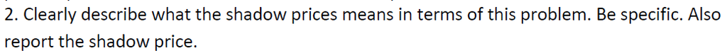

The shadow price for the 1st constraint is 2.666667, meaning profit will increase 2.666667 given an additional board foot of wood. The shadow price for the 2nd constraint is 0 because the constraint is unbounded. Unfinished table has a shadow price of -76.666667, meaning if production of unfinished tables had a constraint of >= 1, profits would drop by -76.666667. The same goes for finished table and unfinished chair which have shadow prices of -6.666667 and -50. Increasing the constraint for finished chair would not change profit.

```r
s$duals
```

```
## [1]   2.666667   0.000000 -76.666667  -6.666667 -50.000000   0.000000
```